# Part II: Serovar Specific DESeq: Salmonella Heidelberg

Hannah Blackwell and Chelsey Patch

2024-04-03

# Introduction, Part I

In Part I, differential gene expression of *Salmonella enterica* isolates was analyzed to determine how these signatures varied between the three serovars tested: Heidelberg, Typhimurium, and monophasic Typhimurium. We hypothesized that the gene expression observed in the monophasic Typhimurium and Typhimurium isolates would be distinct from the Heidelberg isolates, as the former two groups are more closely related. This anaylsis will analyze three isolates that are specifically *Salmonella enterica* serovar Heidelberg, and evaluate differences in gene expression to better understand what is potentially attributed to these differences. RNA-seq was performed on six outbreak-associated strains from four different outbreaks. The isolate naming scheme used was iso#_serovar_foodsource_replicate#. There were three biological replicates for each isolate.

The wet-lab methods were as follows:

1. Bacterial cultures were grown.
2. RNA extracted in stationary phase with the PureLink RNA Mini Kit (Invitrogen).
3. rRNA depletion with NEBNext rRNA Depletion Kit (Bacteria) from New England Biolabs and again with the Zymo RiboFree Assay kit by the Vermont Integrative Genomics Core.
4. Sequencing by the Vermont Integrative Genomics Core with the Illumina HiSeq (150 bp paired-end) on two flow cells.

The Vermont Integrative Genomics Core transferred the 72 FASTQ files us via Globus, we uploaded our the Vermont Advanced Computing Center (VACC) home directories. In the VACC, the FASTQ files were organized as follows:

1. The files, respective of forward and backward read, replicate number, and sample were concatenated to combine reads from the two different flow cells.
2. Quality assessment was performed with FastQC v.0.11.7 and MultiQC v.1.0.
3. Illumina adapters and reads with phred scores of less tha 20 were trimmed with Trimgalore v.0.6.4 and Cutadapt v.4.6.
4. Quality assessment was performed a second time, adapter contamination was gone.
5. The FASTQ files were aligned to the *Salmonella enterica* subsp. *enterica* serovar Heidelberg str. SL476 reference genome ASM2070v1 (GCF_000020705.1).
6. Counting was performed with HTSeq v.0.11.2.

Finally, we proceeded with the differential expression (DE) analysis below. In the directory with this Rmarkdown script, there are a number of additional files necessary to run this script fully. This includes:

- 18 *_sorted.counts files
- “salmonella_annotation_BlackwellPatch.csv” to specify the sample/serovar that the count files were derived from

### All Heidelberg Isolates (1, 4 and 5)

### Load the Required Libraries

```r
library(knitr)
library(DESeq2)
library(RColorBrewer)
library(pheatmap)
library(ggplot2)
library(tidyverse)
library(EnhancedVolcano)
library(biomaRt)
library(dplyr)
library(tidyr)
library(cowplot)
library(ggplotify)
```

### Input Counts

First, we will load the annotation file called `salmonella_annotation_BlackwellPatch.csv` below, then filter to only include the *Salmonella* Heidelberg.

```r
sampleTable <- read.csv("salmonella_annotation_BlackwellPatch.csv", header = TRUE, sep = ",")

heidelberg_matrix <- sampleTable %>%
  filter(serovar == "Heidelberg")
heidelberg_matrix <- data.frame(heidelberg_matrix)
```

Next, we will specify factors. We will specify the columns “serovar”, “outbreak”, “Source”, and “Heat_Shock” as a factors.

```r
#specify serovar as a factor
serovar <- factor(heidelberg_matrix$serovar)

#specify outbreak as a factor
outbreak <- factor(heidelberg_matrix$outbreak)

#specify source as a factor
Source <- factor(heidelberg_matrix$Source)

#specify heat shock level as a factor
#number of minutes indicates survival time of the isolate experiencing heat stress, so higher num. of minutes indicates more heat tolerant strain
heattolerance <- factor(heidelberg_matrix$Heat_Shock)
```

# Running DESeq2

### *All Heidelberg*

Design will be by outbreak. One of the isolates is from the Foster Farms outbreak (1), and two isolates are from the Kosher liver outbreak (4 and 5).

```r
#DE Seq set up
ddsHTSeq_heidelberg <- DESeqDataSetFromHTSeqCount(heidelberg_matrix,
                                       directory = ".",
                                       design= ~ outbreak)
```

### Pre-Filtering

We can filter the rows to only keep those that have at least 30 reads total.

```r
#keep 30 reads and above
keep <- rowSums(counts(ddsHTSeq_heidelberg)) >= 30
ddsHTSeq_heidelberg <- ddsHTSeq_heidelberg[keep,]
```

### Running the Differential Expression Analysis

#### *All Heidelberg*

We will set the contrast to outbreak.

```r
#run DE Seq and create object for results
ddsHTSeq_heidelberg <- DESeq(ddsHTSeq_heidelberg)
results_heidelberg <- results(ddsHTSeq_heidelberg, contrast = c("outbreak", "foster_farms", "kosher_liver"))
```

We can now order our results table by the smallest *padj* value, then filter:

```r
#order results
result <- results_heidelberg[order(results_heidelberg$padj), ]

#filter by p-adj
table(result$padj<0.05)
```

```
##
## FALSE  TRUE
##  4382   198
```

### Merging the results above with the normalized counts data

Now, we can **merge** the above output (i.e. `result`) with the normalized counts data (i.e. `ddsHTSeq_heidelberg`).

```r
#merging
resdata_heidelberg <- merge(as.data.frame(result), as.data.frame(counts(ddsHTSeq_heidelberg, normalized=TRUE)), by="row.names", sort=FALSE)
```

Next, we can relabel the first column `Gene_id` using the `names()` function.

```r
#rename first column
names(resdata_heidelberg)[1] <- "Gene_id"

#write results into a csv
write.csv(resdata_heidelberg, file="Heidelberg_matrix.csv")
```

# Data transformation and visualization

### Principal components analysis (PCA)

Now we will make a PCA plot. Each data point represents one sample. The x-axis, PC1, explains the largest source of variation in the dataset, which in this case is the outbreak from which the *Salmonella* Heidelberg isolates were obtained. We can see that the isolates are clustering by outbreak. Now, we can dive deeper into pairwise comparisons by specific isolate and source.

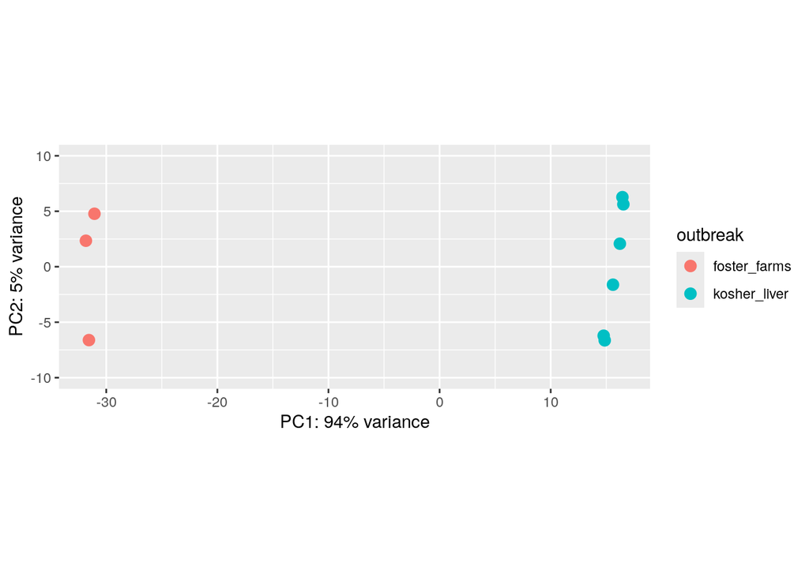

```r
#PCA
heidelberg_counts <- DESeq2::vst(ddsHTSeq_heidelberg, blind = FALSE)
pca_heidelberg <- plotPCA(heidelberg_counts, intgroup=c("outbreak"), returnData=TRUE)
percentVar <- round(100 * attr(pca_heidelberg, "percentVar"))
ggplot(pca_heidelberg, aes(PC1, PC2, color=outbreak)) +
  geom_point(size=3) +
  ylim(-10,10) +
  xlab(paste0("PC1: ",percentVar[1],"% variance")) +
  ylab(paste0("PC2: ",percentVar[2],"% variance")) +
  coord_fixed()
```

**Figure 1. PCA plot of all nine Heidelberg isolates, clearly clustering by outbreak** There is a 94% variance between the three Foster Farms chicken isolates and six Kosher Liver isolates (PC1), and a 5% variance between the groups of isolates themselves (PC2).’

# Pairwise Comparison Between Heidelberg Isolates

Isolates 1, 4, and 5 are *Salmonella* Heidelberg; 4 and 5 are from the same outbreak, but they are all from different sources: * Iso 1 = chicken tenderloin * Iso 4 = fresh chicken liver * Iso 5 = broiled chicken liver

## Pairwise Comparison 1: Iso 1 and Iso 4

#### Import and Format Data

The next steps are very similar to above, as we are calling in the sample table to filter and keep only the isolates of interest. We will then re-specify factors before performing DE Seq.

```r
#Filter origional sample table to select only Iso 1 and Iso 4, create a dataframe
iso_1v4_matrix <- dplyr::slice(sampleTable, -(4:9), -(13:18))
iso_1v4_matrix <- data.frame(iso_1v4_matrix)
```

Next, we will specify factors. We will specify the columns “outbreak”, “Source” and “Heat_Shock” as factors.

```r
#specify outbreak as a factor
outbreak <- factor(iso_1v4_matrix$outbreak)

#specify source as a factor
Source <- factor(iso_1v4_matrix$Source)

#specify heat shock level as a factor, the number of minutes indicates survival time of the isolate experiencing heat stress (so higher value indicates a more heat tolerant strain)
heattolerance <- factor(iso_1v4_matrix$Heat_Shock)
```

# DE Seq

### *Pairwise 1: Iso 1 and Iso 4*

We will select design by outbreak. We expect to see a greater difference by outbreak rather than by source or level of heat shock, and we are hoping to compare our findings to epidemiological and clinical relevance of the outbreak.

```r
#Run DESeq
ddsHTSeq_heidelberg_1v4 <- DESeqDataSetFromHTSeqCount(iso_1v4_matrix,
                                       directory = ".",
                                       design= ~ outbreak)
```

### Pre-Filtering

We can filter the rows to only keep those that have at least 30 reads total. Right now we have 4,754 rows. Notice that line 1 is creating an object called `keep` that will identify any row greater than or equal to 30.

```r
keep <- rowSums(counts(ddsHTSeq_heidelberg_1v4)) >= 30
ddsHTSeq_heidelberg_1v4 <- ddsHTSeq_heidelberg_1v4[keep,]
```

### Running the Differential Expression Analysis

#### *Pairwise 1: Iso 1 and Iso 4*

The standard differential expression analysis steps are wrapped into a single function, `DESeq()`. The estimation steps performed by this function are described in the manual page for `?DESeq`.

```r
ddsHTSeq_heidelberg_1v4 <- DESeq(ddsHTSeq_heidelberg_1v4)
```

### Extracting a Table to Show the Results

We will use the `contrast` argument, and contrast by outbreak.

```r
#contrast
results_heidelberg_1v4 <- results(ddsHTSeq_heidelberg_1v4, contrast = c("outbreak", "foster_farms", "kosher_liver"))

#in order by p adj value
result_1v4 <- results_heidelberg_1v4[order(results_heidelberg_1v4$padj), ]

table(result_1v4$padj<0.05)
```

```
##
## FALSE  TRUE
##  4430   148
```

### Merging the results above with the normalized counts data

Now, we can **merge** the above output (i.e. `result`) with the normalized counts data (i.e. `ddsHTSeq_heidelberg`).

```r
#merging
resdata_heidelberg_1v4 <- merge(as.data.frame(result_1v4), as.data.frame(counts(ddsHTSeq_heidelberg_1v4, normalized=TRUE)), by="row.names", sort=FALSE)
```

```r
#rename column
names(resdata_heidelberg_1v4)[1] <- "Gene_id"

#write results into a csv
write.csv(resdata_heidelberg_1v4, file="resdata_heidelberg_1v4.csv")
```

# Data transformation and visualization

### *Pairwise 1: Iso 1 and Iso 4*

### Principal components analysis (PCA)

Now we will make a PCA plot. Each data point represents one sample. The x-axis, PC1, explains the largest source of variation in the dataset, which in this case is the outbreak from which the *Salmonella* Heidelberg isolates were obtained. We can see that the isolates are clustering by outbreak. Now, we can dive deeper into pairwise comparisons by specific isolate and source.

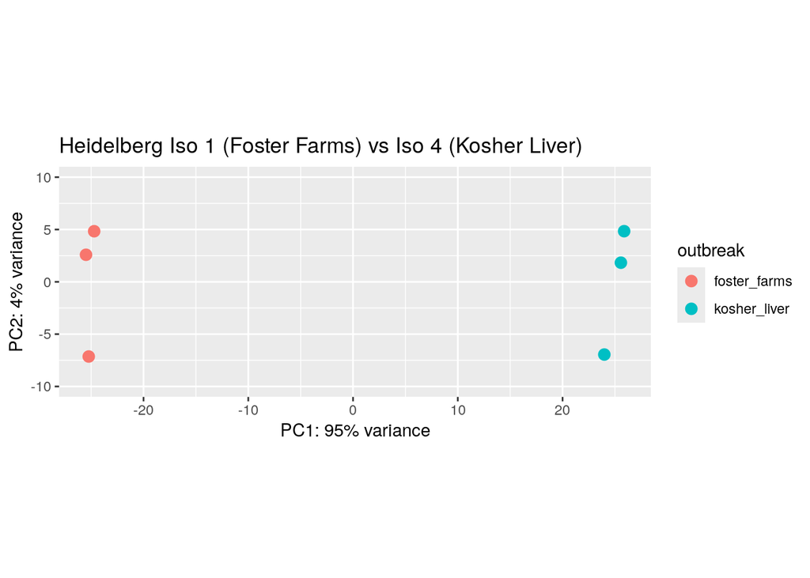

```r
#PCA
heidelberg_counts_1v4 <- DESeq2::vst(ddsHTSeq_heidelberg_1v4, blind = FALSE)

#creating an object and changing
pca_heidelberg_1v4 <- plotPCA(heidelberg_counts_1v4, intgroup=c("outbreak"), returnData=TRUE)
percentVar <- round(100 * attr(pca_heidelberg_1v4, "percentVar"))
ggplot(pca_heidelberg_1v4, aes(PC1, PC2, color=outbreak)) +
  geom_point(size=3) +
  ylim(-10,10) +
  xlab(paste0("PC1: ",percentVar[1],"% variance")) +
  ylab(paste0("PC2: ",percentVar[2],"% variance")) +
  coord_fixed() +
  ggtitle("Heidelberg Iso 1 (Foster Farms) vs Iso 4 (Kosher Liver)")
```

```r
ggsave("Heidelberg_1v4_PCA.png")
```

**Figure 2. PCA plot shows clustering by outbreak.** There is a 95% PC1 variance by outbreak, and a 4% PC2 variance between respective outbreaks’ replicates, indicating that there are variations among replicates within each isolate, but the isolates of different outbreaks are vastly different.

# Correlation Heatmap

### *Pairwise 1 : Iso 1 and Iso 4*

This will visualize the relationship between the samples.

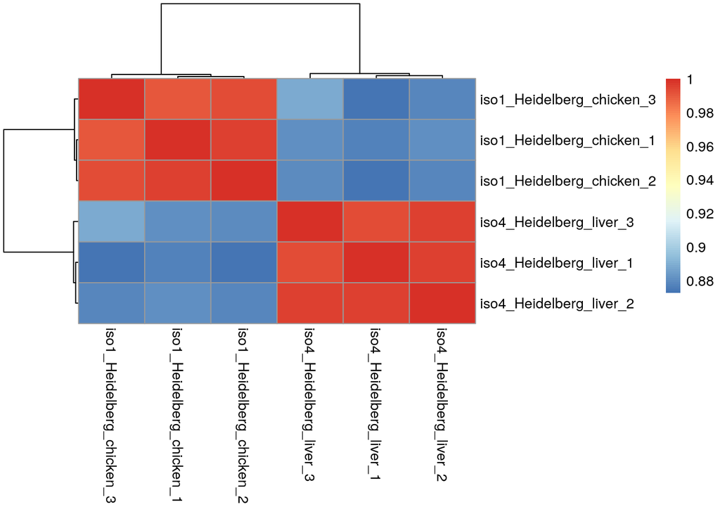

```r
rld <- rlog(ddsHTSeq_heidelberg_1v4, blind=FALSE)
rld_mat <- assay(rld)
rld_cor <- cor(rld_mat)
pheatmap(rld_cor)
```

```r
ggsave("Heidelberg_1v4_CorHeatMap.png")
```

**Figure 3. Correlation heatmap between Isolate 1 chicken samples (three reps) and Isolate 4 liver samples (three reps) shows distinctive clustering by outbreak.**

# Volcano Plot

### *Pairwise 1 : Iso 1 and Iso 4*

First, we need to add a column that specifies whether the data is differentially expressed or not. This threshold will filter based on the *p adjusted* value, and will `TRUE` will mean that it has a value of <0.05.

```r
#filter
threshold_padj_1v4 <- resdata_heidelberg_1v4$padj < 0.05
length(which(threshold_padj_1v4))
```

```
## [1] 148
```

```r
#Add vector as a column (threshold) to the resdata
resdata_heidelberg_1v4$threshold <- threshold_padj_1v4
```

```r
#Add a column to dataframe to specify up or down regulated, then specify
resdata_heidelberg_1v4$diffexpressed <- "Unchanged"
resdata_heidelberg_1v4$diffexpressed[resdata_heidelberg_1v4$padj < 0.05 & resdata_heidelberg_1v4$log2FoldChange > 1] <- "Upregulated"
resdata_heidelberg_1v4$diffexpressed[resdata_heidelberg_1v4$padj < 0.05 & resdata_heidelberg_1v4$log2FoldChange < -1] <- "Downregulated"
```

Next we can filter out results to include ONLY data with a *P-adj* of 0.05 or less, and a log 2 fold change of greater than 1.

```r
resdata_sig_heidelberg_1v4 <- as.data.frame(resdata_heidelberg_1v4) %>% dplyr::filter(abs(log2FoldChange) > 1 & padj < 0.05)
```

```r
# Count the number of rows where diffexpressed is "Upregulated"
upregulated_count_heidelberg_1v4 <- nrow(resdata_sig_heidelberg_1v4[resdata_sig_heidelberg_1v4$diffexpressed == "Upregulated", ])
upregulated_count_heidelberg_1v4
```

```
## [1] 122
```

```r
downregulated_count_heidelberg_1v4 <- nrow(resdata_sig_heidelberg_1v4[resdata_sig_heidelberg_1v4$diffexpressed == "Downregulated", ])
downregulated_count_heidelberg_1v4
```

```
## [1] 1
```

Now we can actually create the volcano plot!

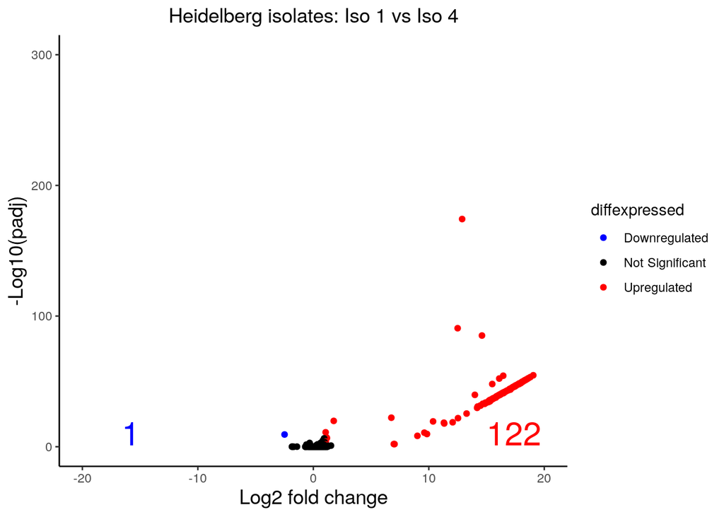

```r
p <- ggplot(resdata_heidelberg_1v4) +
        geom_point(aes(x=log2FoldChange,
                       y=-log10(padj), colour=diffexpressed)) +
  theme_classic() +
        ggtitle("Heidelberg isolates: Iso 1 vs Iso 4") +
        xlab("Log2 fold change") +
        ylab("-Log10(padj)") +
        theme(legend.position = "right",
              plot.title = element_text(size = rel(1.25), hjust = 0.5),
              axis.title = element_text(size = rel(1.25))) +
  scale_color_manual(values = c("blue", "black", "red"),
                     labels = c("Downregulated", "Not Significant", "Upregulated")) +
  scale_x_continuous(limits = c(-20, 20)) +
  coord_cartesian(ylim=c(0, 300), clip = "off")

  # Add annotation
p + annotate("text", x = 15, y = 10, label = "122", colour = "red", size = 8, hjust = 0) +
  annotate("text", x = -15, y = 10, label = "1", colour = "blue", size = 8, hjust = 1)
```

```r
ggsave("Heidelberg_1v4_Volcano.png")
```

**Figure 4. Volcano plot shows 122 upregulated genes and 1 downregulated gene in isolate 1 (Foster Farms Outbreak) when compared to isolate 4 (Kosher Liver Outbreak).** Most of these genes are not annotated, and the one downregulated gene is rRNA. It is suspected that this could possibly encode for heightened stress response, but could also potentially be a result of incomplete rRNA depletion.

# Enhanced Volcano Plot

### *Pairwise 1: Iso 1 v Iso 4*

An enhanced volcano plot will label some of the DE genes, as well as showing *which* are are significant by both *P-adj* and log 2 fold change.

```r
#filter
resdata_sig_heidelberg_1v4 <- as.data.frame(resdata_heidelberg_1v4) %>% dplyr::filter(abs(log2FoldChange) > 1 & padj < 0.05)
```

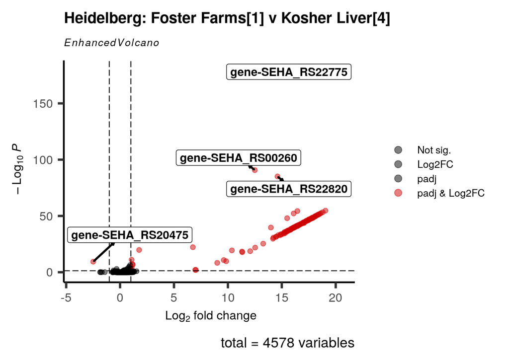

```r
#create enhanced volcano
EnhancedVolcano(resdata_heidelberg_1v4,
                lab = as.character(resdata_heidelberg_1v4$Gene_id),
                x = 'log2FoldChange',
                y = 'padj',
                title = "Heidelberg: Foster Farms[1] v Kosher Liver[4]",
                titleLabSize = 15,
                subtitleLabSize = 10,
                FCcutoff = 1,
                pCutoff = 0.05,
                labSize = 4,
                axisLabSize = 12,
                col=c('black', 'black', 'black', 'red3'),
                labCol = 'black',
                labFace = 'bold',
                boxedLabels = TRUE,
                legendLabels=c('Not sig.','Log2FC','padj', 'padj & Log2FC'),
                legendPosition = 'right',
                legendLabSize = 10,
                legendIconSize = 3.0,
                drawConnectors = TRUE,
                widthConnectors = 1.0,
                colConnectors = 'black',
                gridlines.major = FALSE,
                gridlines.minor = FALSE,
                max.overlaps = 20)
```

```r
ggsave("Heidelberg_1v4_Enhancedvolano.png")
```

**Figure 5. Enhanced volcano plot shows upregulation by p-adj and Log2FC.** Simiarly to the volcano plot, DE genes are overwhelmingly upregulated in the Foster Farms chicken isolate 1 when compared to the Kosher liver isolate 4. Gene-SEHA_RS20475 (unannotated, encodes for rRNA) was downregulated. Gene-SEHA_RS22775 and gene-SEHA_RS00260 are both unannotated. Gene-SEHA_22820 encodes for tet(B) (tetracycline) resistance in the Foster Farms chicken, isolate 1. tet(B) was found in the genome, and tetracycline resistance was cited as a specific clinical issue in the outbreak.

# Heat Map

### *Pairwise 1 : Iso 1 v Iso 4*

A heatmap is another tool used to visualize DE genes among the isolates and replicates within isolates.

```r
#convert into data frame
all_matrix_1v4 <- data.frame(resdata_sig_heidelberg_1v4)
```

```r
#select only iso 1 and iso 4 and gene ID columns
heatmap_matrix_1v4 <- resdata_sig_heidelberg_1v4 %>% dplyr::select(Gene_id, iso1_Heidelberg_chicken_1:iso4_Heidelberg_liver_3)
heatmap_matrix_1v4 <- drop_na(heatmap_matrix_1v4)
heatmap_matrix_1v4 <- data.frame(heatmap_matrix_1v4)
```

```r
#select sample name and outbreak info from meta file
heatmap_meta_1v4 <- iso_1v4_matrix %>%
                    dplyr::select(samplename, outbreak)
heatmap_meta_1v4 <- data.frame(heatmap_meta_1v4)
```

#### Setting Up

```r
# Assign the sample names to be the row names
rownames(heatmap_meta_1v4) <- heatmap_meta_1v4$samplename

#Specify the outbreak
heatmap_meta_1v4 <- dplyr::select(heatmap_meta_1v4, outbreak)


#Re-level factors by outbreak
heatmap_meta_1v4$outbreak <- factor(heatmap_meta_1v4$outbreak,
                                levels = c("foster_farms", "kosher_liver"))

#Aesthetics
heatmap_colors <- rev(brewer.pal(10, "RdBu"))
ann_colors <- list(outbreak = c(foster_farms = "#D11313", kosher_liver = "#6DB0F8"))
```

#### Plotting

```r
#grab the Gene IDs
rownames(heatmap_matrix_1v4) <- heatmap_matrix_1v4$Gene_id
genes_for_heatmap <- grep("Gene_id", colnames(heatmap_matrix_1v4))
heatmap_matrix_1v4 <- heatmap_matrix_1v4[,-genes_for_heatmap]
heatmap_matrix_1v4 <- data.frame(heatmap_matrix_1v4)
```

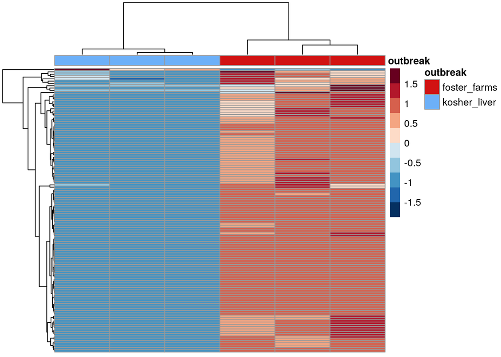

```r
heatmap_1v4 <- as.ggplot(pheatmap(heatmap_matrix_1v4,
         color = heatmap_colors,
         annotation_col = heatmap_meta_1v4,
         annotation_colors = ann_colors,
         show_colnames = FALSE,
         show_rownames = FALSE,
         scale = "row"))
```

```r
ggsave("heatmap_figure_1v4.png")
```

**Figure 6. Heatmap shows downregluation in Iso 4 (Kosher Liver) in most genes when comapred to Iso 1 (Foster Farms chicken).** Overall, there is less variation among the Kosher liver Iso 4 samples, and more variation between the Iso 1 Foster Farms isolates. Despite uniformity among most DE genes, there is upregulation in one gene in one rep in the Kosher liver isolate. Similarly, in that same rep, there is downregulation among all three Iso 1 reps.

# Boxplots

### *Pairwise 1 : Iso 1 v Iso 4*

Boxplots will help us to visualize a few selected genes of interest so more closely investigate their differential expression.

#### Data Input

We will be using `all_matrix_1v4` and `heatmap_meta_1v4`

```r
#files
head(all_matrix_1v4)
```

```
##             Gene_id  baseMean log2FoldChange     lfcSE     stat        pvalue
## 1 gene-SEHA_RS22775 12645.345       12.88613 0.4521659 28.49869 1.216049e-178
## 2 gene-SEHA_RS00260  5267.191       12.49762 0.6050720 20.65476  8.845504e-95
## 3 gene-SEHA_RS22820 15126.485       14.60285 0.7300353 20.00294  5.192277e-89
## 4 gene-SEHA_RS00055 45717.286       19.04702 1.1813897 16.12256  1.771243e-58
## 5 gene-SEHA_RS00050 27156.368       16.44527 1.0240578 16.05893  4.950419e-58
## 6 gene-SEHA_RS00315 38356.275       18.79374 1.1822737 15.89627  6.725057e-57
##            padj iso1_Heidelberg_chicken_1 iso1_Heidelberg_chicken_2
## 1 5.567073e-175                  22675.56                  28150.23
## 2  2.024736e-91                  10332.36                  11820.67
## 3  7.923415e-86                  28034.71                  32861.80
## 4  2.027188e-55                  93682.04                  92809.25
## 5  4.532604e-55                  55417.62                  55113.39
## 6  5.131219e-54                  74490.29                  82833.78
##   iso1_Heidelberg_chicken_3 iso4_Heidelberg_liver_1 iso4_Heidelberg_liver_2
## 1                 25036.781                5.802579                1.060267
## 2                  9445.141                4.973639                0.000000
## 3                 29859.088                3.315759                0.000000
## 4                 87812.429                0.000000                0.000000
## 5                 52405.264                0.000000                1.060267
## 6                 72813.576                0.000000                0.000000
##   iso4_Heidelberg_liver_3 threshold diffexpressed
## 1               2.6380856      TRUE   Upregulated
## 2               0.0000000      TRUE   Upregulated
## 3               0.0000000      TRUE   Upregulated
## 4               0.0000000      TRUE   Upregulated
## 5               0.8793619      TRUE   Upregulated
## 6               0.0000000      TRUE   Upregulated
```

```r
head(heatmap_meta_1v4)
```

```
##                               outbreak
## iso1_Heidelberg_chicken_1 foster_farms
## iso1_Heidelberg_chicken_2 foster_farms
## iso1_Heidelberg_chicken_3 foster_farms
## iso4_Heidelberg_liver_1   kosher_liver
## iso4_Heidelberg_liver_2   kosher_liver
## iso4_Heidelberg_liver_3   kosher_liver
```

#### Data Manipulation

This is to narrow down to a handful of DE genes.

```r
#narrowing down DE genes
order_matrix_1v4_top20 <- arrange(all_matrix_1v4, padj) %>%
                          dplyr::select(Gene_id, iso1_Heidelberg_chicken_1:iso4_Heidelberg_liver_3) %>%
                          dplyr::slice_head(n=20)
```

```r
#expression plot
expression_plot_1v4 <- tidyr::pivot_longer(order_matrix_1v4_top20,
                                cols = 2:7,
                                values_to = "normalized_counts")
```

```r
#Adding outbreak column to pivoted data frame
expression_plot_1v4$outbreak <- rep(c("foster_farms", "foster_farms", "foster_farms", "kosher_liver", "kosher_liver", "kosher_liver"),times=20)
expression_plot_1v4 <- data.frame(expression_plot_1v4)
```

## Creating Boxplots for Genes of interest

I will be selecting `gene-SEHA_RS22775`, `gene-SEHA_RS00260`, and `gene-SEHA_RS22820`; which were all upregulated in the Foster Farms chicken outbreak when compared to the Kosher Liver outbreak.

```r
#create expression plots for all
RS22775_exp <- expression_plot_1v4 %>%
  filter(Gene_id == "gene-SEHA_RS22775")

RS00260_exp <- expression_plot_1v4 %>%
  filter(Gene_id == "gene-SEHA_RS00260")

RS22820_exp <- expression_plot_1v4 %>%
  filter(Gene_id == "gene-SEHA_RS22820")
```

```r
#Re-factor the x-axis variable to be in the correct order
RS22775_exp$outbreak <- factor(RS22775_exp$outbreak, levels = c("foster_farms", "kosher_liver"))
```

Now we can make the three box plots for each gene.

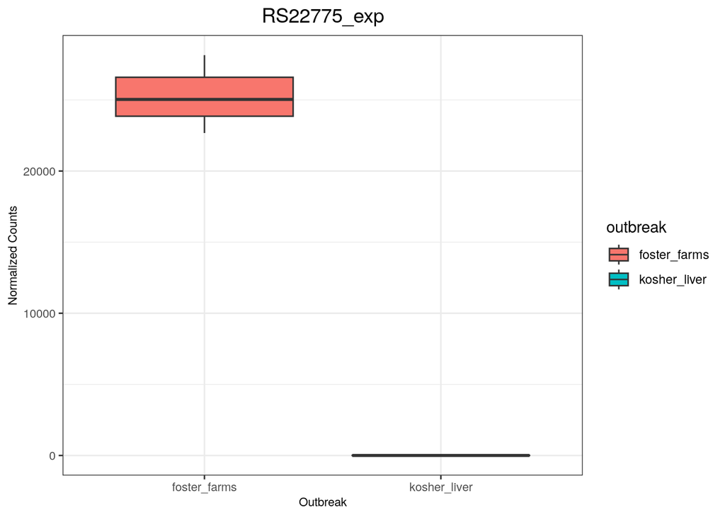

```r
#RS22775
ggplot(RS22775_exp) +
  geom_boxplot(aes(x = outbreak,
                   y = normalized_counts,
                   fill = outbreak)) +
  theme_bw() +
  ggtitle("RS22775_exp") +
  xlab("Outbreak") +
  ylab("Normalized Counts") +
  theme(legend.position = "right",
              plot.title = element_text(size = rel(1.25), hjust = 0.5),
              axis.title = element_text(size = rel(0.75)),
              axis.text = element_text(size = rel(0.75)))
```

```r
ggsave("Hei_1v4_RS22775.png")
```

**Figure 7. Boxplot shows extreme upregulation in Iso 1 Foster Farms when compared to Iso 4 Kosher Liver.** Unfortunately, this gene is not annotated, so it cannot be evaluated extensively. It is interesting to note that the normalized overexpression counts is extremely high.

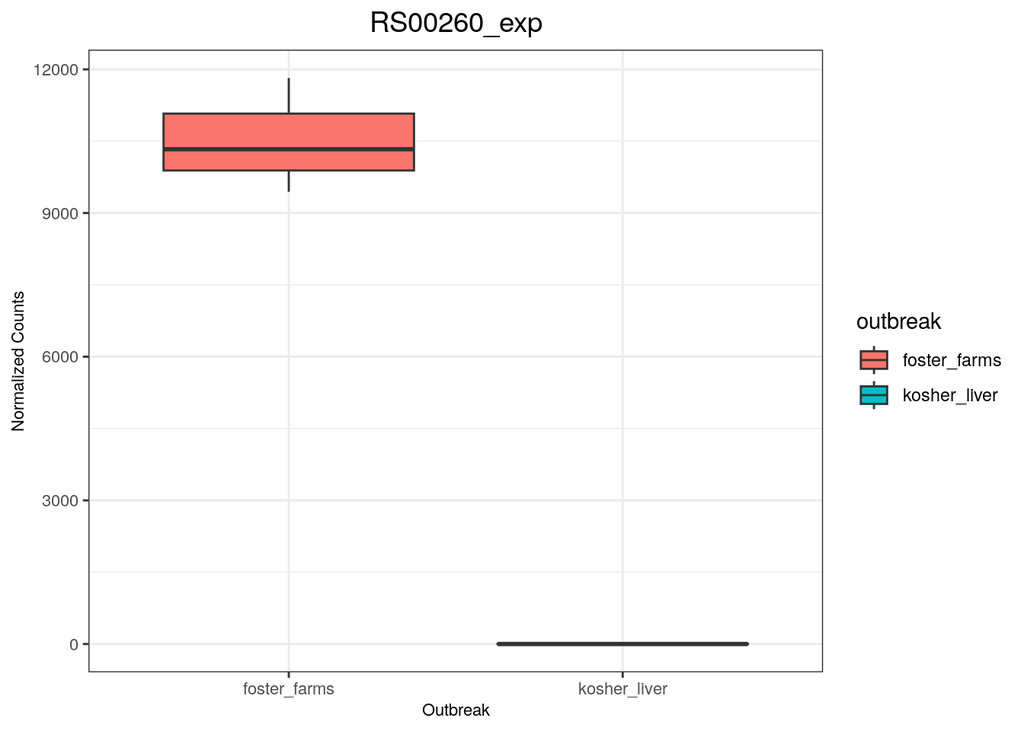

```r
#RS00260
ggplot(RS00260_exp) +
  geom_boxplot(aes(x = outbreak,
                   y = normalized_counts,
                   fill = outbreak)) +
  theme_bw() +
  ggtitle("RS00260_exp") +
  xlab("Outbreak") +
  ylab("Normalized Counts") +
  theme(legend.position = "right",
              plot.title = element_text(size = rel(1.25), hjust = 0.5),
              axis.title = element_text(size = rel(0.75)),
              axis.text = element_text(size = rel(0.75)))
```

```r
ggsave("Hei_1v4_RS00260.png")
```

**Figure 8. Boxplot shows extreme upregulation in Iso 1 Foster Farms when compared to Iso 4 Kosher Liver.** Similarly to Figure 7, this gene is not annotated.

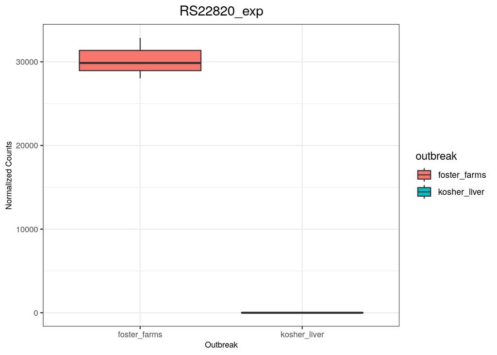

```r
#RS22820
ggplot(RS22820_exp) +
  geom_boxplot(aes(x = outbreak,
                   y = normalized_counts,
                   fill = outbreak)) +
  theme_bw() +
  ggtitle("RS22820_exp") +
  xlab("Outbreak") +
  ylab("Normalized Counts") +
  theme(legend.position = "right",
              plot.title = element_text(size = rel(1.25), hjust = 0.5),
              axis.title = element_text(size = rel(0.75)),
              axis.text = element_text(size = rel(0.75)))
```

```r
ggsave("Hei_1v4_RS22820.png")
```

**Figure 9. Boxplot shows extreme upregulation in Iso 1 Foster Farms when compared to Iso 4 Kosher Liver.** This gene is annotated, and encodes for tet(B), tetracycline resistance. As mentioned earlier, tetracycline resistance was cited to be an issue in the outbreaks. In the Foster Farms outbreak, 65% of isolates were drug resistant, and 35% were multidrug resistant. There was an extremely high hospitalization rate of 38%, and invasive illness was seen at a much higher rate (15%) than normal (5%).

# Pairwise Comparison 2: Iso 1 and Iso 5

#### Import and Format Data

```r
#Call in sampleTable
head(sampleTable)
```

```
##                  samplename               filename isolate replicate
## 1 iso1_Heidelberg_chicken_1 iso1_rep1_sorted.count       1         1
## 2 iso1_Heidelberg_chicken_2 iso1_rep2_sorted.count       1         2
## 3 iso1_Heidelberg_chicken_3 iso1_rep3_sorted.count       1         3
## 4      iso2_MonoTyph_pork_1 iso2_rep1_sorted.count       2         1
## 5      iso2_MonoTyph_pork_2 iso2_rep2_sorted.count       2         2
## 6      iso2_MonoTyph_pork_3 iso2_rep3_sorted.count       2         3
##        serovar     outbreak             Source Heat_Shock
## 1   Heidelberg foster_farms chicken_tenderloin       <NA>
## 2   Heidelberg foster_farms chicken_tenderloin       <NA>
## 3   Heidelberg foster_farms chicken_tenderloin       <NA>
## 4 I(4,5,12);i-   roast_pork              swine     60_min
## 5 I(4,5,12);i-   roast_pork              swine     60_min
## 6 I(4,5,12);i-   roast_pork              swine     60_min
```

```r
#Filter to select only Iso 1 and Iso 5, create a dataframe
iso_1v5_matrix <- dplyr::slice(sampleTable, -(4:12), -(16:18))
iso_1v5_matrix <- data.frame(iso_1v5_matrix)
```

Next, we will specify factors. We will specify the columns “outbreak”, “Source” and “Heat_Shock” as factors.

```r
#specify outbreak as a factor
outbreak <- factor(iso_1v5_matrix$outbreak)

#specify source as a factor
Source <- factor(iso_1v5_matrix$Source)

#specify heat shock level as a factor, the number of minutes indicates survival time of the isolate experiencing heat stress (so higher value indicates a more heat tolerant strain)
heattolerance <- factor(iso_1v5_matrix$Heat_Shock)
```

# DE Seq

### *Pairwise 2: Iso 1 v Iso 5*

We will select design by outbreak. We expect to see a greater difference by outbreak rather than by source or level of heat shock, and we are hoping to compare our findings to epidemiological and clinical relevance of the outbreak.

```r
ddsHTSeq_heidelberg_1v5 <- DESeqDataSetFromHTSeqCount(iso_1v5_matrix,
                                       directory = ".",
                                       design= ~ outbreak)
```

### Pre-Filtering

We can filter the rows to only keep those that have at least 30 reads total. Right now we have 4,754 rows. Notice that line 1 is creating an object called `keep` that will identify any row greater than or equal to 30.

```r
keep <- rowSums(counts(ddsHTSeq_heidelberg_1v5)) >= 30
ddsHTSeq_heidelberg_1v5 <- ddsHTSeq_heidelberg_1v5[keep,]
```

### Running the Differential Expression Analysis

The standard differential expression analysis steps are wrapped into a single function, `DESeq()`. The estimation steps performed by this function are described in the manual page for `?DESeq`.

```r
ddsHTSeq_heidelberg_1v5 <- DESeq(ddsHTSeq_heidelberg_1v5)
```

#### Extracting a Table to Show the Results

We will use the `contrast` argument

```r
results_heidelberg_1v5 <- results(ddsHTSeq_heidelberg_1v5, contrast = c("outbreak", "foster_farms", "kosher_liver"))

#in order by p adj value
result_1v5 <- results_heidelberg_1v5[order(results_heidelberg_1v5$padj), ]
```

```r
table(result_1v5$padj<0.05)
```

```
##
## FALSE  TRUE
##  4415   165
```

#### Merging the results above with the normalized counts data

Now, we can **merge** the above output (i.e. `result`) with the normalized counts data (i.e. `ddsHTSeq_heidelberg`).

```r
resdata_heidelberg_1v5 <- merge(as.data.frame(result_1v5), as.data.frame(counts(ddsHTSeq_heidelberg_1v5, normalized=TRUE)), by="row.names", sort=FALSE)
```

```r
#rename just a column... names(object)[column num] <- "new name"
names(resdata_heidelberg_1v5)[1] <- "Gene_id"

#write results into a csv
write.csv(resdata_heidelberg_1v5, file="resdata_heidelberg_1v5.csv")
```

# Data transformation and visualization

### Principal components analysis (PCA)

### *Pairwise 2 : Iso 1 and Iso 5*

Now we will make a PCA plot. Each data point represents one sample. The x-axis, PC1, explains the largest source of variation in the dataset, which in this case is the outbreak from which the *Salmonella* Heidelberg isolates were obtained. We can see that the isolates are clustering by outbreak. Now, we can dive deeper into pairwise comparisons by specific isolate and source.

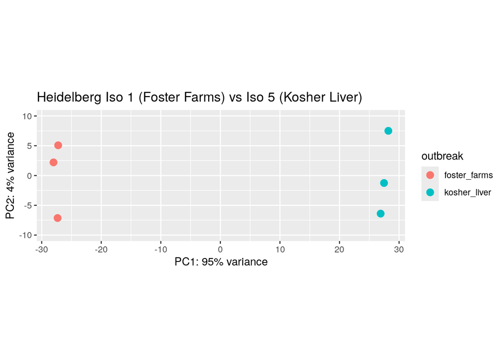

```r
heidelberg_counts_1v5 <- DESeq2::vst(ddsHTSeq_heidelberg_1v5, blind = FALSE)

pca_heidelberg_1v5 <- plotPCA(heidelberg_counts_1v5, intgroup=c("outbreak"), returnData=TRUE)
percentVar <- round(100 * attr(pca_heidelberg_1v5, "percentVar"))
ggplot(pca_heidelberg_1v5, aes(PC1, PC2, color=outbreak)) +
  geom_point(size=3) +
  ylim(-10,10) +
  xlab(paste0("PC1: ",percentVar[1],"% variance")) +
  ylab(paste0("PC2: ",percentVar[2],"% variance")) +
  coord_fixed() +
  ggtitle("Heidelberg Iso 1 (Foster Farms) vs Iso 5 (Kosher Liver)")
```

```r
ggsave("Heidelberg_1v5_PCA.png")
```

# Correlation Heatmap

### *Pairwise 2 : Iso 1 and Iso 5*

This will visualize the relationship between the samples.

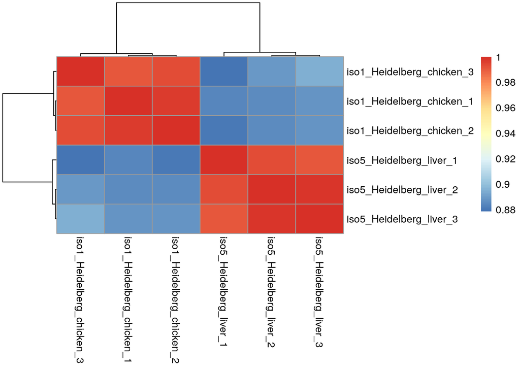

```r
library(pheatmap)
rld <- rlog(ddsHTSeq_heidelberg_1v5, blind=FALSE)
rld_mat <- assay(rld)
rld_cor <- cor(rld_mat)
pheatmap(rld_cor)
```

```r
ggsave("Heidelberg_1v5_CorHeatMap.png")
```

# Volcano Plot

### *Pairwise 2 : Iso 1 and Iso 5*

First, we need to add a column that specifies whether the data is differentially expressed or not. This threshold will filter based on the *p adjusted* value, and will `TRUE` will mean that it has a value of <0.05.

```r
threshold_padj_1v5 <- resdata_heidelberg_1v5$padj < 0.05
length(which(threshold_padj_1v5))
```

```
## [1] 165
```

```r
## Add vector as a column (threshold) to the resdata
resdata_heidelberg_1v5$threshold <- threshold_padj_1v5
```

```r
#Add a column to dataframe to specify up or down regulated
resdata_heidelberg_1v5$diffexpressed <- "Unchanged"

#if log2FC > 1 and padj < 0.05 set as upregulated
resdata_heidelberg_1v5$diffexpressed[resdata_heidelberg_1v5$padj < 0.05 & resdata_heidelberg_1v5$log2FoldChange > 1] <- "Upregulated"

#if log2FC > -1 and padj < 0.05 set as downregulated
resdata_heidelberg_1v5$diffexpressed[resdata_heidelberg_1v5$padj < 0.05 & resdata_heidelberg_1v5$log2FoldChange < -1] <- "Downregulated"
```

```r
#filter
resdata_sig_heidelberg_1v5 <- as.data.frame(resdata_heidelberg_1v5) %>% dplyr::filter(abs(log2FoldChange) > 1 & padj < 0.05)

# Count the number of rows where diffexpressed is "Upregulated"
upregulated_count_heidelberg_1v5 <- nrow(resdata_sig_heidelberg_1v5[resdata_sig_heidelberg_1v5$diffexpressed == "Upregulated", ])

downregulated_count_heidelberg_1v5 <- nrow(resdata_sig_heidelberg_1v5[resdata_sig_heidelberg_1v5$diffexpressed == "Downregulated", ])
```

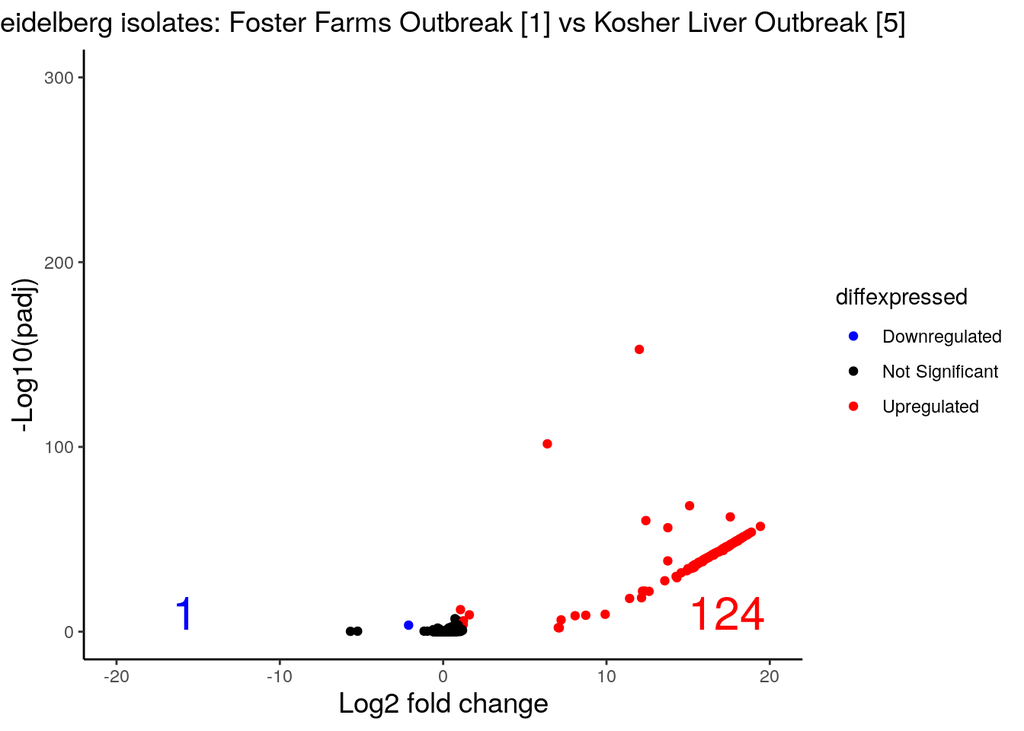

```r
#create plot
p <- ggplot(resdata_heidelberg_1v5) +
        geom_point(aes(x=log2FoldChange,
                       y=-log10(padj), colour=diffexpressed)) +
  theme_classic() +
        ggtitle("Heidelberg isolates: Foster Farms Outbreak [1] vs Kosher Liver Outbreak [5]") +
        xlab("Log2 fold change") +
        ylab("-Log10(padj)") +
        theme(legend.position = "right",
              plot.title = element_text(size = rel(1.25), hjust = 0.5),
              axis.title = element_text(size = rel(1.25))) +
  scale_color_manual(values = c("blue", "black", "red"),
                     labels = c("Downregulated", "Not Significant", "Upregulated")) +
  scale_x_continuous(limits = c(-20, 20)) +
  coord_cartesian(ylim=c(0, 300), clip = "off")

  # Add annotation
p + annotate("text", x = 15, y = 10, label = "124", colour = "red", size = 8, hjust = 0) +
  annotate("text", x = -15, y = 10, label = "1", colour = "blue", size = 8, hjust = 1)
```

```r
ggsave("Heidelberg_1v5_Volcano.png")
```

# Enhanced Volcano Plot

### *Pairwise 2 : Iso 1 and Iso 5*

```r
#filter
resdata_sig_heidelberg_1v5 <- as.data.frame(resdata_heidelberg_1v5) %>% dplyr::filter(abs(log2FoldChange) > 1 & padj < 0.05)
```

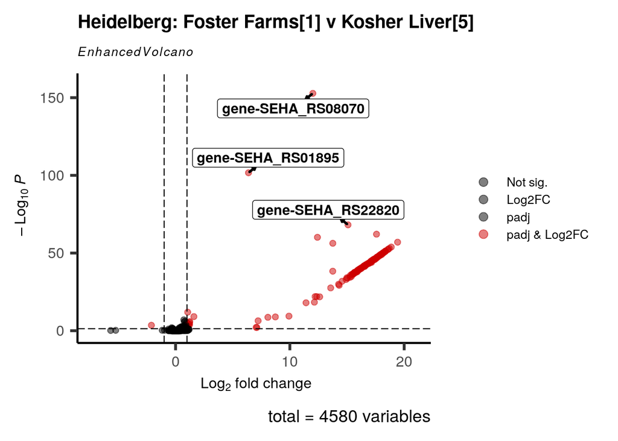

```r
#create plot
EnhancedVolcano(resdata_heidelberg_1v5,
                lab = as.character(resdata_heidelberg_1v5$Gene_id),
                x = 'log2FoldChange',
                y = 'padj',
                title = "Heidelberg: Foster Farms[1] v Kosher Liver[5]",
                titleLabSize = 15,
                subtitleLabSize = 10,
                FCcutoff = 1,
                pCutoff = 0.05,
                labSize = 4,
                axisLabSize = 12,
                col=c('black', 'black', 'black', 'red3'),
                labCol = 'black',
                labFace = 'bold',
                boxedLabels = TRUE,
                legendLabels=c('Not sig.','Log2FC','padj', 'padj & Log2FC'),
                legendPosition = 'right',
                legendLabSize = 10,
                legendIconSize = 3.0,
                drawConnectors = TRUE,
                widthConnectors = 1.0,
                colConnectors = 'black',
                gridlines.major = FALSE,
                gridlines.minor = FALSE,
                max.overlaps = 20)
```

```r
ggsave("Heidelberg_1v5_Enhancedvolano.png")
```

# Heat Map

### *Pairwise 2 : Iso 1 and Iso 5*

First we need to read in the data and set up.

```r
all_matrix_1v5 <- data.frame(resdata_sig_heidelberg_1v5)
```

```r
#select the data of interest
heatmap_matrix_1v5 <- resdata_sig_heidelberg_1v5 %>% dplyr::select(Gene_id, iso1_Heidelberg_chicken_1:iso5_Heidelberg_liver_3)
heatmap_matrix_1v5 <- drop_na(heatmap_matrix_1v5)
heatmap_matrix_1v5 <- data.frame(heatmap_matrix_1v5)
```

```r
#select the data of interest from the meta file
heatmap_meta_1v5 <- iso_1v5_matrix %>%
                    dplyr::select(samplename, outbreak)

heatmap_meta_1v5 <- data.frame(heatmap_meta_1v5)
```

### Setting Up

```r
# Assign the sample names to be the row names
rownames(heatmap_meta_1v5) <- heatmap_meta_1v5$samplename

#Specify the outbreak
heatmap_meta_1v5 <- dplyr::select(heatmap_meta_1v5, outbreak)


#Re-level factors by outbreak
heatmap_meta_1v5$outbreak <- factor(heatmap_meta_1v5$outbreak,
                                levels = c("foster_farms", "kosher_liver"))

#Aesthetics
heatmap_colors <- rev(brewer.pal(10, "RdBu"))
ann_colors <- list(outbreak = c(foster_farms = "#D11313", kosher_liver = "#6DB0F8"))
```

### Plotting

```r
#more set up
rownames(heatmap_matrix_1v5) <- heatmap_matrix_1v5$Gene_id
genes_for_heatmap <- grep("Gene_id", colnames(heatmap_matrix_1v5))
heatmap_matrix_1v5 <- heatmap_matrix_1v5[,-genes_for_heatmap]
heatmap_matrix_1v5 <- data.frame(heatmap_matrix_1v5)
```

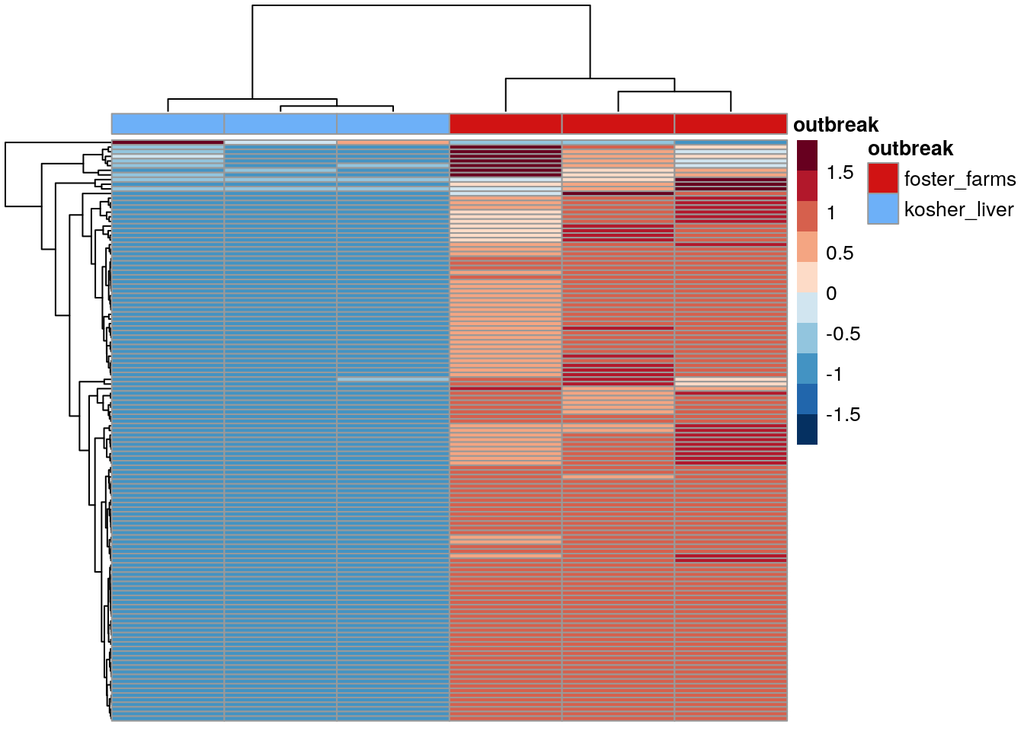

```r
#plotting the heatmap
heatmap_1v5 <- as.ggplot(pheatmap(heatmap_matrix_1v5,
         color = heatmap_colors,
         annotation_col = heatmap_meta_1v5,
         annotation_colors = ann_colors,
         show_colnames = FALSE,
         show_rownames = FALSE,
         scale = "row"))
```

```r
ggsave("heatmap_figure_1v5.png")
```

# Boxplots

### Data Manipulation

This is to narrow down to a handful of DE genes.

```r
#top 20 genes
order_matrix_1v5_top20 <- arrange(all_matrix_1v5, padj) %>%
                          dplyr::select(Gene_id, iso1_Heidelberg_chicken_1:iso5_Heidelberg_liver_3) %>%
                          dplyr::slice_head(n=20)
```

```r
#pivot
expression_plot_1v5 <- tidyr::pivot_longer(order_matrix_1v5_top20,
                                cols = 2:7,
                                values_to = "normalized_counts")
```

```r
#Adding outbreak column to pivoted data frame
expression_plot_1v5$outbreak <- rep(c("foster_farms", "foster_farms", "foster_farms", "kosher_liver", "kosher_liver", "kosher_liver"),times=20)
expression_plot_1v5 <- data.frame(expression_plot_1v5)
```

## Creating Boxplots for Genes of interest

I will be selecting RS08070 and RS01895; which were upregulated in the Foster Farms chicken outbreak when compared to the Kosher Liver outbreak.

```r
#create objects for expression values
RS08070_exp <- expression_plot_1v5 %>%
  filter(Gene_id == "gene-SEHA_RS08070")

RS01895_exp <- expression_plot_1v5 %>%
  filter(Gene_id == "gene-SEHA_RS01895")
```

```r
#Re-factor the x-axis variable to be in the correct order
RS08070_exp$outbreak <- factor(RS08070_exp$outbreak, levels = c("foster_farms", "kosher_liver"))
```

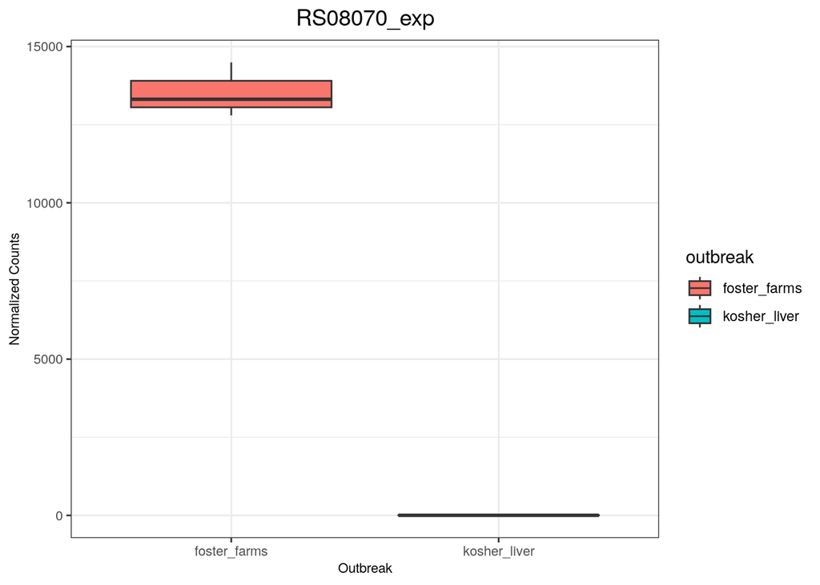

```r
#RS08070
ggplot(RS08070_exp) +
  geom_boxplot(aes(x = outbreak,
                   y = normalized_counts,
                   fill = outbreak)) +
  theme_bw() +
  ggtitle("RS08070_exp") +
  xlab("Outbreak") +
  ylab("Normalized Counts") +
  theme(legend.position = "right",
              plot.title = element_text(size = rel(1.25), hjust = 0.5),
              axis.title = element_text(size = rel(0.75)),
              axis.text = element_text(size = rel(0.75)))
```

```r
ggsave("Hei_1v5_RS08070.png")
```

**Figure 15. Boxplot demonstrating upregulation of gene-SEHA_RS08070 in Iso 1 (Foster Farms chicken) when compared to Iso 5 (Kosher Liver).** This gene encodes for *APH(6), (aminoglycoside O-phosphotransferase).* It inactivates a number of aminoglycoside antibiotics by phosphorylation. One of these antibiotics is streptomycin, which was detected in the genome.

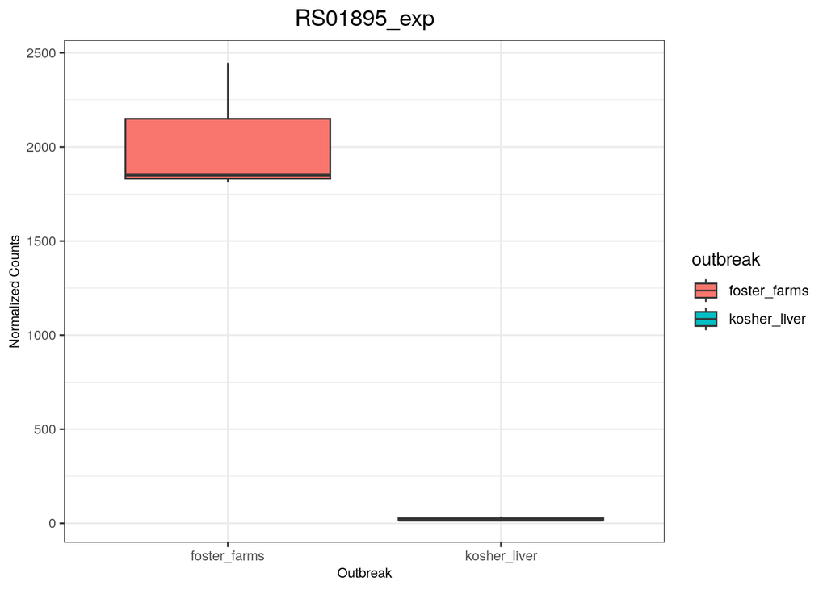

```r
#RS01895
ggplot(RS01895_exp) +
  geom_boxplot(aes(x = outbreak,
                   y = normalized_counts,
                   fill = outbreak)) +
  theme_bw() +
  ggtitle("RS01895_exp") +
  xlab("Outbreak") +
  ylab("Normalized Counts") +
  theme(legend.position = "right",
              plot.title = element_text(size = rel(1.25), hjust = 0.5),
              axis.title = element_text(size = rel(0.75)),
              axis.text = element_text(size = rel(0.75)))
```

```r
ggsave("Hei_1v5_RS01895.png")
```